# Cointegración series BMW y Volkswagen

Marcos Barragán

12/12/2020

## Objetivo:

El objetivo de este subapartado del caso práctico 6 es el estudio de la cointegración entre las series temporales de BMW y Volkswagen.

Se dice que dos series temporales están cointegradas si existe un vector de coeficientes que permite formar una combinación lineal estacionaria entre ambas series. Para determinar esto en el ejercicio que nos concierne analizaremos los resultados de la documentación presentada en la última sesión.

```r
getSymbols('BMW.DE', from = '2014-01-01', to = Sys.Date())
```

[output not shown]

```
## [1] "BMW.DE"
```

```r
BMW <- na.omit(BMW.DE)

BMW <- na.omit(BMW[, 6])

getSymbols('VOW.DE', from = '2014-01-01', to = Sys.Date())
```

```
## [1] "VOW.DE"
```

```r
VW <- na.omit(VOW.DE)

VW <- na.omit(VOW.DE[,6])

BMW_VW <- cbind(BMW, VW)

names(BMW_VW) <- c('BMW', 'VW')

head(BMW_VW)
```

```
##                 BMW       VW
## 2014-01-02 62.47273 167.4914
## 2014-01-03 62.80178 166.6702
## 2014-01-06 62.06143 166.1515
## 2014-01-07 62.48022 167.3185
## 2014-01-08 63.15325 167.0160
## 2014-01-09 62.71204 166.8431
```

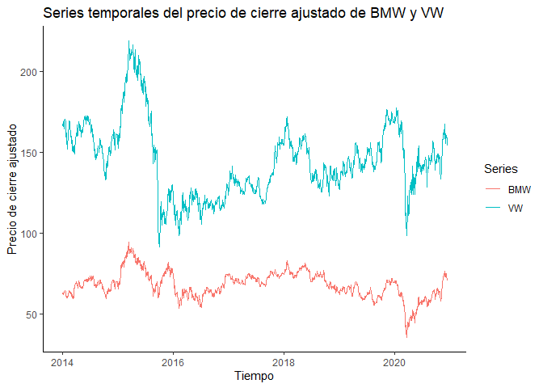

```r
autoplot(BMW_VW, facets = NULL, main = 'Series temporales del precio de cierre ajustado de BMW y VW') +
  xlab("Tiempo") +
  ylab("Precio de cierre ajustado") +
  theme_classic()
```

Nos interesa conocer el carácter estacionario (o no estacionario) de la serie. Para averiguarlo, aplicaremos el test ADF (o prueba Dickey-Fuller aumentada) sobre ambas series temporales, lo que nos devolverá unos resultados de:

```r
adf.test(BMW_VW[, 1], k = 0)
```

```
##
##  Augmented Dickey-Fuller Test
##
## data:  BMW_VW[, 1]
## Dickey-Fuller = -3.1217, Lag order = 0, p-value = 0.1035
## alternative hypothesis: stationary
```

```r
adf.test(BMW_VW[, 2], k = 0)
```

```
##
##  Augmented Dickey-Fuller Test
##
## data:  BMW_VW[, 2]
## Dickey-Fuller = -2.5983, Lag order = 0, p-value = 0.325
## alternative hypothesis: stationary
```

Como vemos, los p-valores de ambas pruebas son superiores al 5%, por lo que no tenemos indicios para rechazar la no estacionariedad de las series (es decir, que consideramos la hipótesis nula de que las series no son estacionarias).

La función *ur.df* del paquete *urca* de R nos permite llevar a cabo un test de augmented Dicker-Fuller como en el caso anterior, pero nos permite introducirle más parámetros. En mi caso, consideraré el método AIC para la valoración y, como comenta en la documentación, llevaré a cabo la implementación del test con la consideración de la tendencia para evitar posibles resultados erróneos.

```r
test_BMW <- ur.df(BMW_VW[, 1], type = "trend", selectlags = "AIC", lags = 12)

summary(test_BMW)
```

```
##
## ###############################################
## # Augmented Dickey-Fuller Test Unit Root Test #
## ###############################################
##
## Test regression trend
##
##
## Call:
## lm(formula = z.diff ~ z.lag.1 + 1 + tt + z.diff.lag)
##
## Residuals:
##     Min      1Q  Median      3Q     Max
## -6.1240 -0.5964 -0.0112  0.5579  5.1635
##
## Coefficients:
##               Estimate Std. Error t value Pr(>|t|)
## (Intercept)  8.645e-01  2.620e-01   3.300 0.000987 ***
## z.lag.1     -1.178e-02  3.516e-03  -3.351 0.000822 ***
## tt          -6.849e-05  5.595e-05  -1.224 0.221043
## z.diff.lag1  5.776e-02  2.392e-02   2.415 0.015854 *
## z.diff.lag2  2.662e-02  2.396e-02   1.111 0.266607
## z.diff.lag3  5.485e-02  2.396e-02   2.289 0.022180 *
## z.diff.lag4 -4.080e-02  2.397e-02  -1.702 0.088942 .
## ---
## Signif. codes:  0 '***' 0.001 '**' 0.01 '*' 0.05 '.' 0.1 ' ' 1
##
## Residual standard error: 1.103 on 1740 degrees of freedom
## Multiple R-squared:  0.01401,    Adjusted R-squared:  0.01061
## F-statistic: 4.121 on 6 and 1740 DF,  p-value: 0.0004079
##
##
## Value of test-statistic is: -3.351 3.7485 5.6154
##
## Critical values for test statistics:
##       1pct  5pct 10pct
## tau3 -3.96 -3.41 -3.12
## phi2  6.09  4.68  4.03
## phi3  8.27  6.25  5.34
```

```r
test_VW <- ur.df(BMW_VW[, 2], type = "trend", selectlags = "AIC", lags = 12)

summary(test_VW)
```

```
##
## ###############################################
## # Augmented Dickey-Fuller Test Unit Root Test #
## ###############################################
##
## Test regression trend
##
##
## Call:
## lm(formula = z.diff ~ z.lag.1 + 1 + tt + z.diff.lag)
##
## Residuals:
##      Min       1Q   Median       3Q      Max
## -24.5805  -1.4736  -0.0201   1.4639  12.1907
##
## Coefficients:
##               Estimate Std. Error t value Pr(>|t|)
## (Intercept)  1.163e+00  4.623e-01   2.516  0.01197 *
## z.lag.1     -8.186e-03  2.949e-03  -2.776  0.00555 **
## tt           1.063e-05  1.323e-04   0.080  0.93602
## z.diff.lag   6.448e-02  2.391e-02   2.696  0.00708 **
## ---
## Signif. codes:  0 '***' 0.001 '**' 0.01 '*' 0.05 '.' 0.1 ' ' 1
##
## Residual standard error: 2.759 on 1743 degrees of freedom
## Multiple R-squared:  0.00819,    Adjusted R-squared:  0.006483
## F-statistic: 4.798 on 3 and 1743 DF,  p-value: 0.00248
##
##
## Value of test-statistic is: -2.7764 2.6565 3.9762
##
## Critical values for test statistics:
##       1pct  5pct 10pct
## tau3 -3.96 -3.41 -3.12
## phi2  6.09  4.68  4.03
## phi3  8.27  6.25  5.34
```

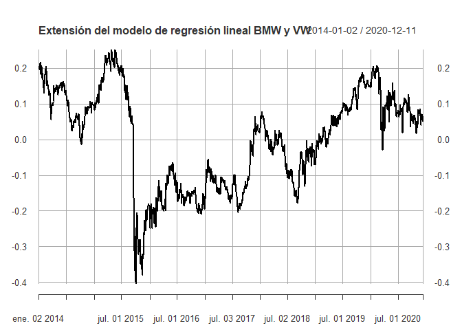

```r
#Estimate parameters & plot spread

mod_lineal <- EstimateParameters(BMW_VW, method = lm)

#str(mod_lineal)

plot(mod_lineal$spread, main = 'Extensión del modelo de regresión lineal BMW y VW')
```

Ahora debemos asegurarnos de la estacionariedad de la serie compuesta por ambos activos. Para ello, emplearé la función *IsStationary* de R, que nos devuelve el carácter estacionario (o no estacionario) de la serie una vez le especificamos el p-value que queremos considerar como mínimo. En mi caso, como en el resto de la práctica, consideraré un 5% como valor de significación para confirmar o rechazar hipótesis.

```r
IsStationary(mod_lineal$spread, 0.05)
```

```
##  PP.test adf.test
##    FALSE    FALSE
```

Ambos test nos devuelven que la hipótesis de que la nueva serie sea estacionaria es falsa, y, por ende, debamos rechazar (a ese nivel de significaión) la hipótesis de estacionariedad. Posteriormente, probé con un nivel de significación mayor (10%) obteniendo el mismo resultado.

Esto se podría haber conseguido a partir de una representación de ambas series utilizando los coeficientes de intercept que salían en el test de *ur.df*. Si construyésemos la serie conjunto a partir de dichos valores, tendríamos:

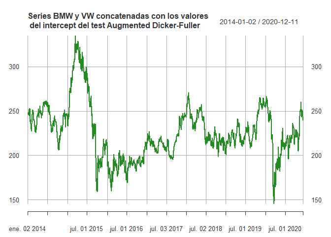

```r
union_series <- 0.86*BMW_VW[, 1] + 1.16*BMW_VW[, 2]

plot(union_series, type="l", col = 'forestgreen', main = 'Series BMW y VW concatenadas con los valores \n del intercept del test Augmented Dicker-Fuller')
```

```r
adf.test(union_series)
```

```
##
##  Augmented Dickey-Fuller Test
##
## data:  union_series
## Dickey-Fuller = -2.778, Lag order = 12, p-value = 0.2489
## alternative hypothesis: stationary
```

Vemos que el resultado arrojado es consistente con los anteriores, pues obtenemos que no podemos considerar la estacionariedad de las series, por lo que aseveramos que ambas series no están cointegradas.

## Anexo:

### Estimación del Hidden Markov Model (HMM) para el caso de BMW:

```r
rm(list=ls())

library(depmixS4)
library(TTR)
library(ggplot2)
library(reshape2)
library(xts)
library(extrafont)
library(quantmod)
```

```r
getSymbols('BMW.DE', from = '2014-01-01', to = Sys.Date())
```

```
## [1] "BMW.DE"
```

```r
# Despreciamos los NA's:

BMW <- na.omit(BMW.DE)
```

Realmente los que nos interesan son los precios de cierre ajustados:

```r
BMW_adj <- BMW$BMW.DE.Adjusted

colnames(BMW_adj) <- c("Close")
```

A continuación utilizo una función para transformar los datos a semanales. Seguiré para ello el script presentado en clase.

```r
semanal = function(BMW_adj){

  aa <- seq.Date(as.Date(min(index(BMW_adj))),
                 length.out = 2 + as.numeric(as.Date(max(index(BMW_adj))) - as.Date(min(index(BMW_adj)))),
                 by="1 days")

  bb <- xts(rep(NA, length(aa)), aa)

  cc <- bb[time(bb[.indexwday(bb) == 5])]

  dd <- sapply(1:(length(cc) - 1),
               function(x) last(BMW_adj[seq.Date(as.Date(time(cc[x])), as.Date(time(cc[x + 1])),1)]))

  coredata(cc[2:(length(cc))]) <- dd

  return(cc)
}


BMW_adj_weekly = semanal(BMW_adj)

colnames(BMW_adj_weekly) <- c("Close")
```

```r
BMW_adj_weekly$Rent <- log(BMW_adj_weekly$Close) - lag(log(BMW_adj_weekly$Close), k=2)


BMW_adj_weekly <- na.exclude(BMW_adj_weekly)
```

Transformamos el XTS en un DataFrame para poder operar con él, y le añadimos la fecha considerada:

```r
BMW_adj_weekly <- data.frame(BMW_adj_weekly)

# Poner la fecha que esta en el nombre de la fila como columna de fecha con formato

BMW_adj_weekly$Fecha <- as.Date(row.names(BMW_adj_weekly), "%Y-%m-%d")
```

Aquí definiremos el modelo HHM Markov con dos estados. Explicaremos la rentabilidad en función de la constante.

```r
modelo_HHM <- depmix(Rent ~ 1,
              family = gaussian(),
              nstates = 2,
              data = BMW_adj_weekly)

set.seed(2020)
```

Estimamos ese modelo y representamos un resumen de los resultados junto con él.

```r
fit_HHM <- fit(modelo_HHM, verbose = FALSE)
```

```
## converged at iteration 65 with logLik: 548.153
```

```r
summary(fit_HHM)
```

```
## Initial state probabilities model
## pr1 pr2
##   1   0
##
## Transition matrix
##         toS1  toS2
## fromS1 0.965 0.035
## fromS2 0.151 0.849
##
## Response parameters
## Resp 1 : gaussian
##     Re1.(Intercept) Re1.sd
## St1           0.001  0.042
## St2           0.001  0.101
```

```r
print(fit_HHM)
```

```
## Convergence info: Log likelihood converged to within tol. (relative change)
## 'log Lik.' 548.153 (df=7)
## AIC:  -1082.306
## BIC:  -1055.103
```

La probabilidad de encontrarnos en cada estado viene dada por:

```r
probab <- posterior(fit_HHM)

BMW_adj_weekly$pState <- probab[,1]

BMW_adj_weekly$pBull <- probab[,2]

BMW_adj_weekly$pBear <- probab[,3]
```

```r
#Nombre a la Primera columna

colnames(BMW_adj_weekly)[1] <- "BMW"

df_ggplot <- melt(BMW_adj_weekly[,c(1,2,3,4,5,6)],
           id = "Fecha",
           measure = c("BMW","Rent","pBull","pBear","pState"))


##Gráfico Probabilidad
positivoColor <- subset(df_ggplot, df_ggplot$variable == "Rent")

pColor=ifelse(positivoColor$value >=0, "blue", "red")
```

Representamos el HMM en nuestro caso, como se vio en los documentos presentados en clase:

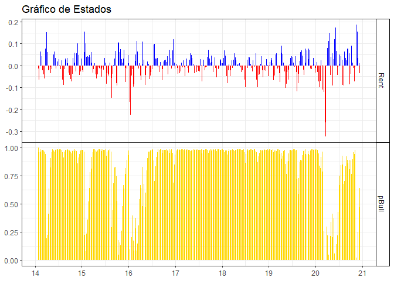

```r
f <- ggplot()+
  geom_step(data = subset(df_ggplot, df_ggplot$variable == "nameStock"),
            aes(Fecha, value)) +
  geom_linerange(data = positivoColor,
                 aes(Fecha, value, ymin = 0, ymax = value),
                 color = pColor) +
  geom_linerange(data = subset(df_ggplot, df_ggplot$variable == "pBull"),
                 aes(Fecha, value, ymin=0, ymax=value),
                 color="gold") +
  facet_grid(variable ~.,
             scales = "free",
             as.table = TRUE) +
  scale_x_date(date_breaks = "1 years",
               date_labels = "%y") +
  theme_bw() +
  theme(panel.spacing = unit(0, "lines"), axis.title.x = element_blank(),
        axis.title.y = element_blank(),
        strip.background = element_rect(colour = "black", fill = "white")) +
  ggtitle("Gráfico de Estados")

f
```

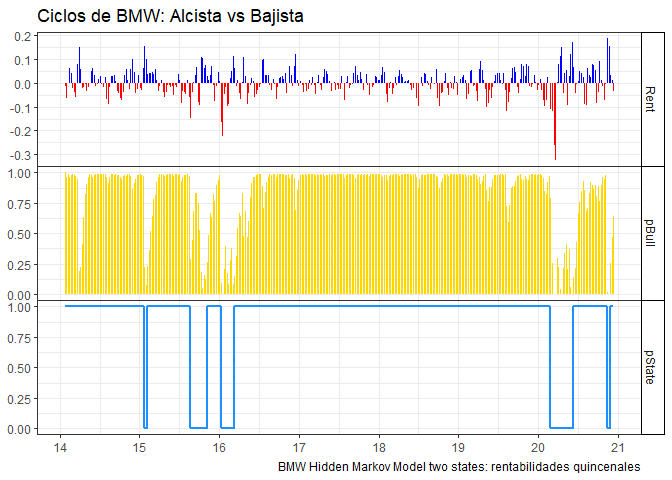

```r
f <- ggplot() +
  geom_step(data = subset(df_ggplot, df_ggplot$variable == "nameStock"),
            aes(Fecha, value)) +
  geom_linerange(data = positivoColor,
                 aes(Fecha, value, ymin = 0, ymax = value),
                 color = pColor) +
  geom_linerange(data = subset(df_ggplot, df_ggplot$variable == "pBull"),
                 aes(Fecha, value,ymin = 0, ymax = value),
                 color = "gold") +
  geom_step(data = subset(df_ggplot, df_ggplot$variable == "pState"),
            aes(Fecha, 2 - value),
            color = "dodgerblue",
            size = 1) +
  facet_grid(variable ~.,
             scales = "free",
             as.table = TRUE) +
  scale_x_date(date_breaks = "1 years",
               date_labels = "%y") +
  theme_bw() +
  theme(panel.spacing = unit(0, "lines"), axis.title.x = element_blank(),
        axis.title.y = element_blank(),
        strip.background = element_rect(colour = "black", fill = "white")) +
  ggtitle("Ciclos de BMW: Alcista vs Bajista") +
  labs(caption = "BMW Hidden Markov Model two states: rentabilidades quincenales")

f
```